# Analyse textuelle des tweets de Donald Trump

Jonathan DAHAN

# Introduction

- Journalistes + Donald Trump = Love Story
- Data: quel genre d’histoire ?
- Analyse effectuée avec R
- Slides: http://rpubs.com/JDAHAN/trump_analyse
- Todd Vaziri, [David Robinson](https://twitter.com/drob), [Julia Silge](https://twitter.com/juliasilge)

# Extraction des tweets

```r
lapply(c("twitteR","dplyr","purrr"),require,character.only=T)

options(httr_oauth_cache=T)
setup_twitter_oauth(
  consumer_key="some_special_key",
  consumer_secret="what_a_secret",
  access_token="access_here",
  access_secret="the_secret"
)
tweets<-userTimeline("realDonaldTrump",
                     n = 3200)
tweets_df<-tbl_df(map_df(tweets,
                         as.data.frame))
```

# On obtient quoi ?

Table continues below

| text | created | statusSource | favoriteCount | retweetCount |
| --- | --- | --- | --- | --- |
| FAKE NEWS - A TOTAL POLITICAL WITCH HUNT! | 2017-01-11 01:19:23 | [Twitter for Android](http://twitter.com/download/android) | 96302 | 30080 |

| longitude | latitude | id |
| --- | --- | --- |
| NA | NA | 818990655418617856 |

# Activité

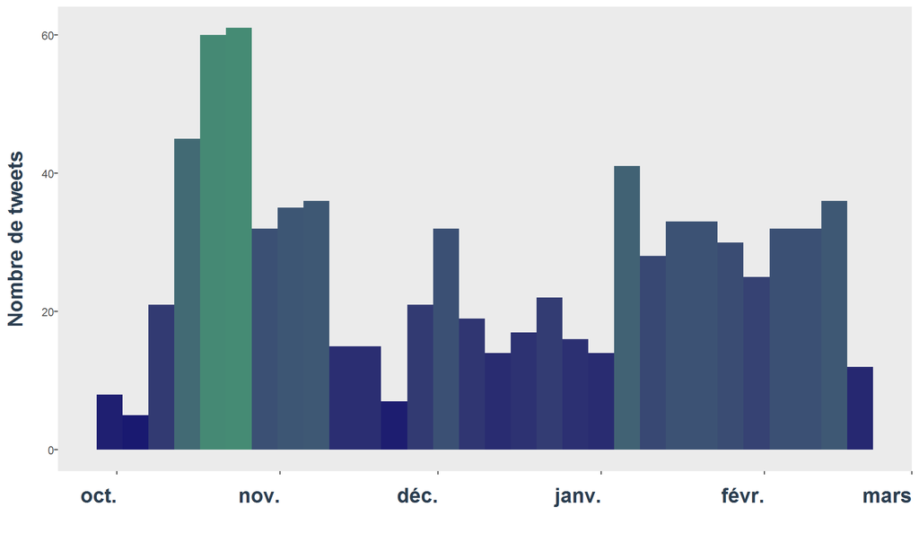

# À quelle heure ?

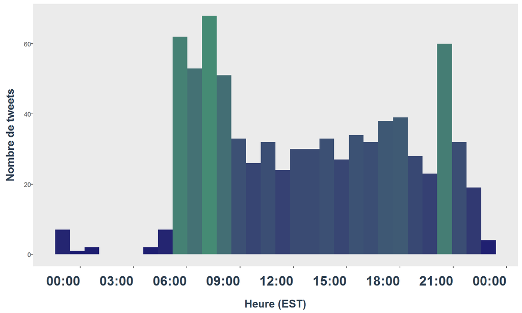

# Tweets nocturnes ?

“Just tried watching Saturday Night Live - unwatchable! Totally biased, not funny and the Baldwin impersonation just can’t get any worse”

# Popularité

- nombre moyen de retweets par tweet ?
- nombre moyen d’ajouts en favoris par tweet ?

# Popularité

- RTs/tweet ~ 19400
- FVs/tweet ~ 73300

# Top RTs/tweet

| text | favoriteCount | created | statusSource | retweetCount |
| --- | --- | --- | --- | --- |
| TODAY WE MAKE AMERICA GREAT AGAIN! | 573876 | 2016-11-08 06:43:14 | [Twitter for Android](http://twitter.com/download/android) | 345630 |

# Top FV’s/tweet

Table continues below

| text | favoriteCount | created |
| --- | --- | --- |
| Such a beautiful and important evening! The forgotten man and woman will never be forgotten again. We will all come together as never before | 634231 | 2016-11-09 06:36:58 |

| statusSource | retweetCount |
| --- | --- |
| [Twitter for Android](http://twitter.com/download/android) | 221418 |

# Trump, il poste quoi ?

[figure not shown]

# Mots vides

- “the”, “she”, “from”, “about”
- français: “le”, “il”, “dans”
- pas de signification propre: inutile de les indexer

# Des hashtags ?

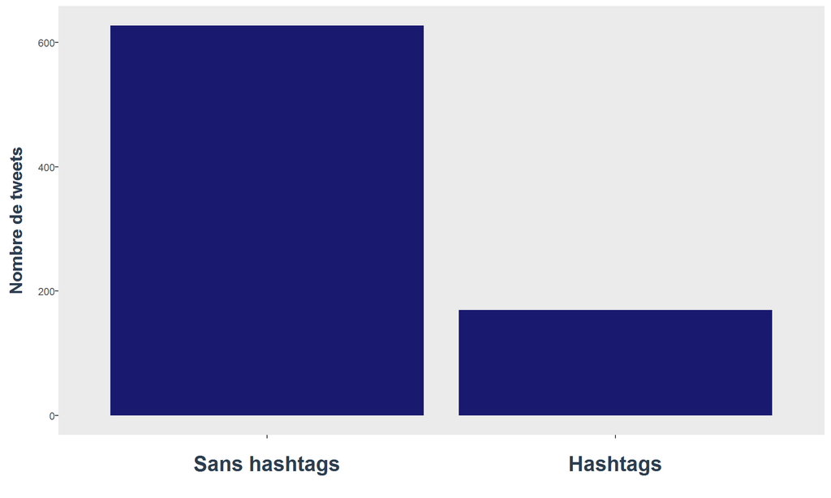

# Combien de caractères ?

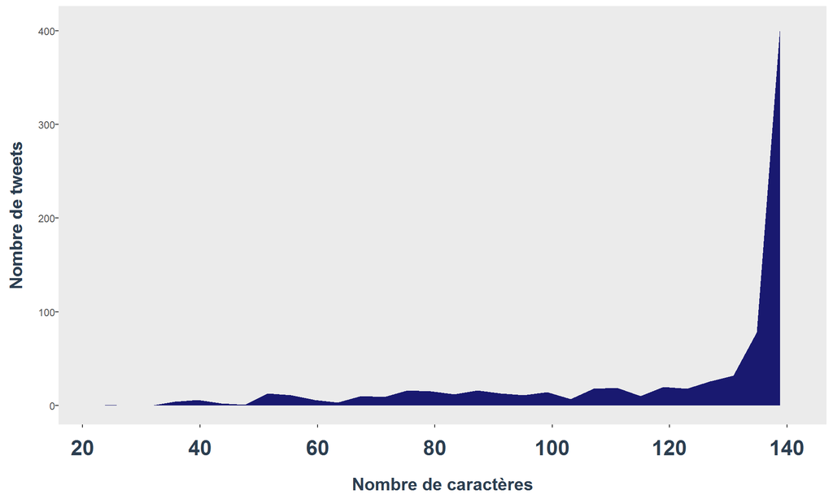

# D’où sont postés les tweets ?

| Source | % |
| --- | --- |
| Android | 50.9 |
| iPhone | 42.8 |
| Web Client | 5.8 |
| iPad | 0.3 |
| Periscope | 0.1 |
| Twitter | 0.1 |

# Fil quotidien

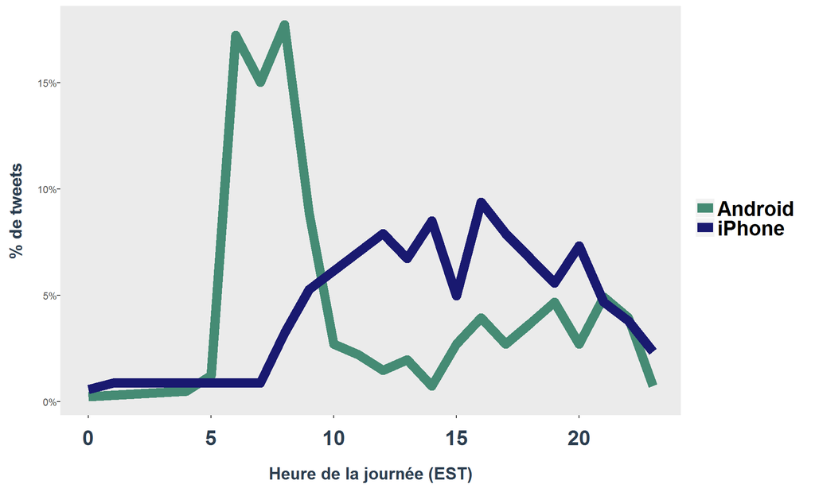

# Hypothèse

- iPhone = équipe de campagne, Android = Trump
- http://www.theverge.com/2015/10/5/9453935/donald-trump-twitter-strategy
- https://www.cnet.com/news/trumps-tweets-android-for-nasty-iphone-for-nice/

# Partage d’images/liens

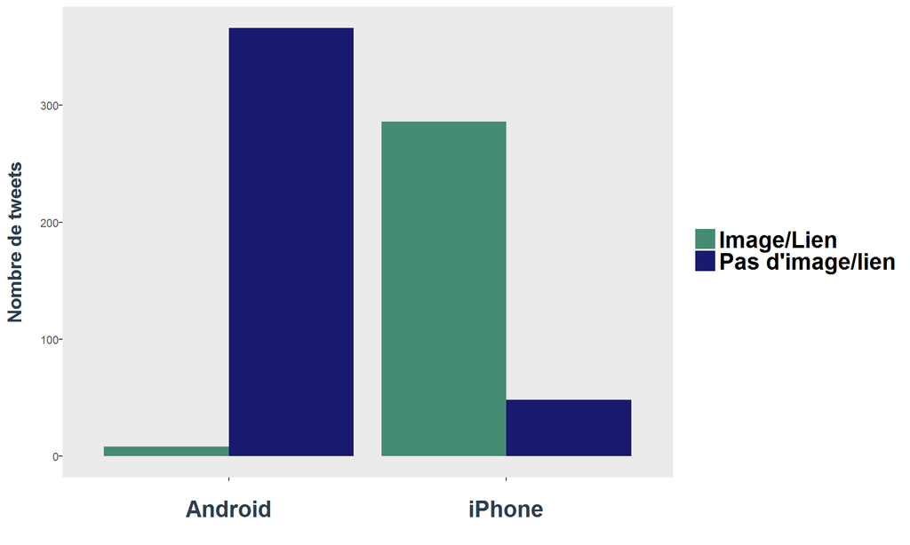

# iPhone Vs Android: contenus

- Utilisation du ratio log-odds
- “fake”: + chances d’être posté par l’iPhone ou Android ?
- Comparer des proportions

# Ratio log-odds

$$\log_2(\frac{\frac{\mbox{nb Android} + 1}{\mbox{total Android} + 1}} {\frac{\mbox{nb iPhone} + 1}{\mbox{total iPhone} + 1}})$$

# log-odds: exemple

Android –> 3 fois / 10 000
iPhone –> 1 fois / 10 000
$$\text{log-odds}=\log_2(\frac{\frac{\mbox{4}}{\mbox{10001}}} {\frac{\mbox{2}}{\mbox{10001}}})$$
$$log_2(2^{1})=1$$

# log-odds: iPhone Vs Android

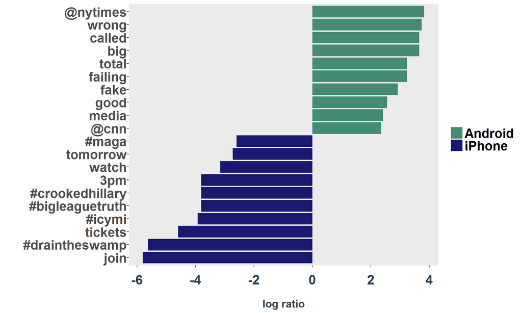

# Contenus

- iPhone: plus de hashtags
- iPhone: plus de mots pour des annonces (“7pm”, “3pm”, “join”, “tickets”)
- Android: plus de mots à charge émotionnelle négative (“fake”, “illegal”,“badly”, “failing”)

# Tweets / iPhone

- Annonces, événements…
- “Join me in Florida this Saturday at 5pm for a rally at the Orlando-Melbourne International Airport!”

# Tweets / Android

- d’un autre type…
- “The FAKE NEWS media (failing @nytimes, @NBCNews, @ABC, @CBS, @CNN) is not my enemy, it is the enemy of the American People!”

# Sentiments

- NRC Word-Emotion Association Lexicon
- à chaque mot est associé le sentiment qu’il produit
- “trust”, “fear”,“negative”, “sadness”, “anger”, “surprise”, “positive”, “disgust”, “joy”, “anticipation”

# De quoi ça a l’air ?

| word | sentiment |
| --- | --- |
| fake | negative |
| illegal | anger |
| illegal | disgust |
| illegal | fear |
| failing | fear |
| failing | anger |
| failing | sadness |

# L’heure du bilan

| Source | Sentiments | % |
| --- | --- | --- |
| Android | negative, anger, disgust, fear, sadness | 33.2 |
| iPhone | negative, anger, disgust, fear, sadness | 15.9 |

# Sentiments: et Mélenchon ?

http://www.lirmm.fr/~abdaoui/publications/FEEL.pdf

| - | + |
| --- | --- |
| 62.9 % | 10.1 % |